# GRR signal

```r
library(scater)
library(scran)
library(scuttle)
library(tidyverse)
library(AUCell)
library(fgsea)
library(readxl)

knitr::opts_knit$set(root.dir = here::here())
```

When looking at GC subcluster-specific leading edge enrichment we see that MUT spg are enriched for several terms that should have high activity in spermatocytes and spermatids, while spermatocytes are enriched for developmental terms.

```r
enr <- read_rds("results/enrichment/gsea_prerank.rds") |> map_df(as_tibble,.id="comparison") |> filter(padj < 0.05)

library(tidytext)
enr |>
  filter(str_detect(comparison,"Spermat")) |>
  filter(str_detect(pathway,"SPERM|MEIO|PLURI|GAMETE|DEV")) |>
  filter(padj <0.05) |>
  group_by(comparison, sign(NES)) |>
  slice_max(abs(NES),n=10) |>
  ungroup() |>
  mutate(pathway = tidytext::reorder_within(pathway,sign(NES)*-log10(padj),comparison)) |>
  arrange(NES) |>
  ggplot(aes(sign(NES)* -log10(padj),pathway,fill=factor(sign(NES)))) +
  geom_col() +
  scale_y_reordered() +
  facet_wrap(~comparison,scales="free") +
  theme(axis.text.y = element_text(size=rel(1))) +
  scale_fill_manual(values = c(`-1`="blue",`1`="red"))
```

[output not shown]

I see maybe some relation to Soygur et al. 2021 *Sci. Adv.* They looked at fetal mouse ovary (so not a perfect comparison, of course) and saw that bridge depletion by Tex14 knockout desynchronizes meiotic entry, presumably due to inconsistent sharing of cell-state coordinating factors, e.g. Dppa3.

> …we found that genes implicated in the pluripotency program such as Sox2 and Pou5f1 were also down-regulated in Sycp3high meiotic germ cells in Tex14−/− (fig. S6C). Such selective loss of a specific group of transcripts subset in Tex14−/− , which lacks cytoplasmic bridges, argues against the possibility that severed bridges during dissociation alter the transcriptome indiscriminately.

> …

> We found that cytoplasmic sharing through Tex14-dependent ICBs is crucial not only for the radial meiotic wave but also for appropriate timing of meiotic initiation. Upon initiation of meiosis, Tex14 mutant germ cells more abruptly deplete transcripts associated with pluripotency such as Dppa3.

```r
sce <- read_rds('results/germ_cells/adult.sce.germ_cell.both_genotypes.subclustered.reintegrated.rds')
```

Genes plotted below are pluripotency markers highlighted by Soygur et al.

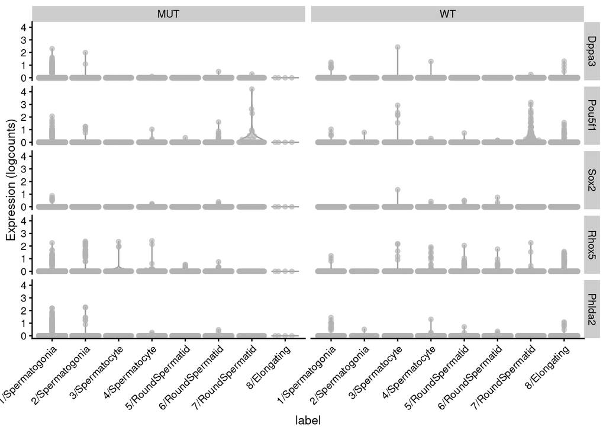

```r
plotExpression(sce,c("Dppa3","Pou5f1","Sox2","Rhox5","Phlda2"),x="label",swap_rownames = "gene_name",other_fields = "genotype") +
  facet_grid(Feature~genotype) + theme(axis.text.x = element_text(angle=45, hjust=1))
```

```r
lkup <- rowData(sce)[,c("gene_id","gene_name")] |> as_tibble() |> dplyr::rename(feature="gene_id")
de <- read_tsv("results/differential_expression/adult.tbl.germ_cell.reprocessed.de.tsv.gz") |>
  left_join(lkup, by="feature") |> dplyr::relocate(gene_name,.before="feature")
filter(de, gene_name %in% c("Dppa3","Pou5f1","Sox2","Rhox5","Phlda2"))
```

```
# A tibble: 1 × 8
  celltype        gene_name feature            logFC logCPM     F PValue   FDR
  <chr>           <chr>     <chr>              <dbl>  <dbl> <dbl>  <dbl> <dbl>
1 1/Spermatogonia Phlda2    ENSMUSG00000010760 0.729   3.85  3.49 0.0666 0.574
```

## Stemness/demethylation signature?

GRR genes are derived from Hill et al 2018 *Nature*.

```r
m5 <- fgsea::gmtPathways("data/m5.all.v2023.2.Mm.symbols.gmt")

m5 <- m5[str_detect(names(m5),"MEIO|MALE_GAMETE")]

grr <- read_xlsx("~/Downloads/41586_2018_BFnature25964_MOESM3_ESM.xlsx",col_names = "gene_name") |> pull(gene_name)

line1s <- read_tsv("data/dfam_classification.parsed.txt") |>
  filter(classification == "LINE" & dfam_name %in% de$feature) |>
  filter(str_detect(classification_long,"L1$")) |>
  pull(dfam_name)

sigs <- c(list(GRR=grr,LINE1s=line1s),m5)
```

```r
mat <- counts(sce)
rownames(mat) <- rowData(sce)$gene_name

rankings <- AUCell_buildRankings(mat,splitByBlocks = T,
                                 plotStats=F, verbose=FALSE)
```

[output not shown]

[output cut: 40 more lines]

[output not shown]

```r
# default aucMaxRank = 0.05, but grr is a very small list ~45 genes, so doesn't make sense to cut it that much
scsig.aucs <- AUCell_calcAUC(sigs, rankings,aucMaxRank = ceiling(0.5 * nrow(rankings)),verbose = T,nCores = 4)
```

```
Using 4 cores with doMC.
```

```
Genes in the gene sets NOT available in the dataset:
    GRR:    7 (16% of 45)
    GOBP_ACTIVATION_OF_MEIOSIS:     1 (14% of 7)
    GOBP_CHROMOSOME_ORGANIZATION_INVOLVED_IN_MEIOTIC_CELL_CYCLE:    2 (3% of 72)
    GOBP_DOUBLE_STRAND_BREAK_REPAIR_INVOLVED_IN_MEIOTIC_RECOMBINATION:  1 (8% of 13)
    GOBP_FEMALE_GAMETE_GENERATION:  8 (4% of 179)
    GOBP_FEMALE_MEIOSIS_I:  1 (7% of 14)
    GOBP_FEMALE_MEIOTIC_NUCLEAR_DIVISION:   2 (4% of 45)
    GOBP_HOMOLOGOUS_CHROMOSOME_PAIRING_AT_MEIOSIS:  2 (4% of 57)
    GOBP_MALE_GAMETE_GENERATION:    38 (5% of 696)
    GOBP_MALE_MEIOSIS_I:    1 (3% of 29)
    GOBP_MALE_MEIOTIC_NUCLEAR_DIVISION:     1 (2% of 61)
    GOBP_MEIOSIS_I_CELL_CYCLE_PROCESS:  3 (2% of 139)
    GOBP_MEIOTIC_CELL_CYCLE:    7 (2% of 349)
    GOBP_MEIOTIC_CELL_CYCLE_PROCESS:    5 (2% of 238)
    GOBP_MEIOTIC_CHROMOSOME_SEGREGATION:    3 (3% of 100)
    GOBP_MEIOTIC_DNA_DOUBLE_STRAND_BREAK_FORMATION:     1 (14% of 7)
    GOBP_MEIOTIC_SPINDLE_ASSEMBLY:  1 (8% of 13)
    GOBP_MEIOTIC_SPINDLE_ORGANIZATION:  1 (5% of 22)
    GOBP_POSITIVE_REGULATION_OF_MEIOTIC_CELL_CYCLE:     1 (3% of 32)
    GOBP_POSITIVE_REGULATION_OF_MEIOTIC_NUCLEAR_DIVISION:   1 (5% of 21)
    GOBP_REGULATION_OF_MEIOTIC_CELL_CYCLE:  1 (2% of 60)
    GOBP_REGULATION_OF_MEIOTIC_NUCLEAR_DIVISION:    1 (3% of 38)
    GOBP_SPINDLE_ASSEMBLY_INVOLVED_IN_FEMALE_MEIOSIS:   1 (11% of 9)
    GOCC_MEIOTIC_SPINDLE:   2 (11% of 18)
```

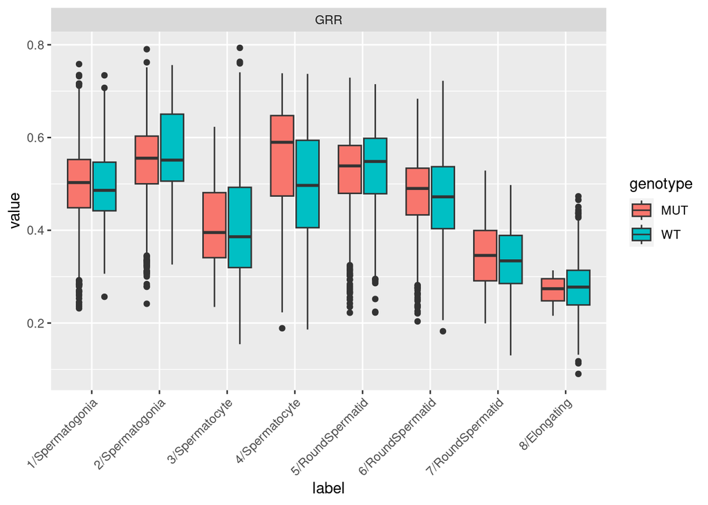

```r
scsig.aucs <- t(assay(scsig.aucs))

stopifnot(all(rownames(scsig.aucs) == colnames(sce)))

dat <- scsig.aucs |>
  as_tibble(rownames="cell") |>
  mutate(label = sce$label, genotype = sce$genotype) |>
  dplyr::relocate(label,genotype,.after=cell) |>
  pivot_longer(-c(cell,label,genotype))


plot_signature <- function(x) {
  return(dat |>
           filter(name==x) |>
           ggplot(aes(label,value,fill=genotype)) +
           facet_wrap(~name, scales="free") +
           geom_boxplot())
}

plot_signature("GRR") + theme(axis.text.x = element_text(angle=45, hjust=1))
```

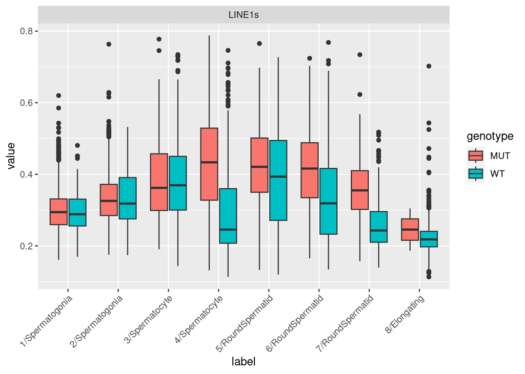

```r
plot_signature("LINE1s") + theme(axis.text.x = element_text(angle=45, hjust=1))
```

4/spermatocyte cells (and to a lesser extent round spermatids) with more GRR activation also experience more LINE1 activation.

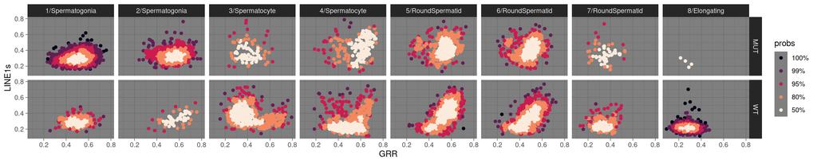

```r
dat |>
  pivot_wider(names_from = "name",values_from = "value") |>
  #filter(label %in% c("4/Spermatocyte")) |>
  ggplot(aes(GRR,LINE1s)) +
  #geom_point() +
  ggdensity::geom_hdr_points() +
  #geom_point() +
  facet_grid(genotype~label) +
  theme_dark() +
  scale_color_viridis_d(option = "F")
```

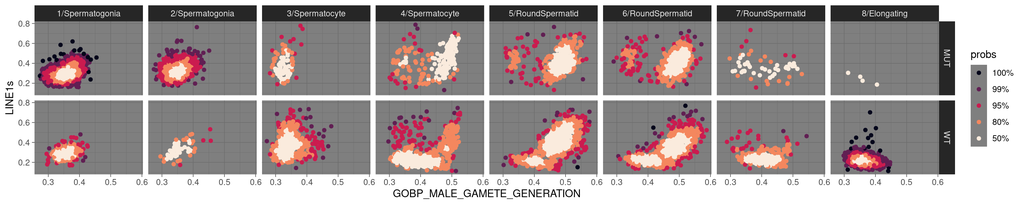

```r
dat |>
  pivot_wider(names_from = "name",values_from = "value") |>
  #filter(label %in% c("4/Spermatocyte")) |>
  ggplot(aes(GOBP_MALE_GAMETE_GENERATION,LINE1s)) +
  #geom_point() +
  ggdensity::geom_hdr_points() +
  #geom_point() +
  facet_grid(genotype~label) +
  theme_dark() +
  scale_color_viridis_d(option = "F")
```

```r
sce_4sp_mut <- sce[,sce$label == "4/Spermatocyte" & sce$genotype == "MUT"]

rownames(sce_4sp_mut)
```

[output not shown]

[output cut: 11159 more lines]

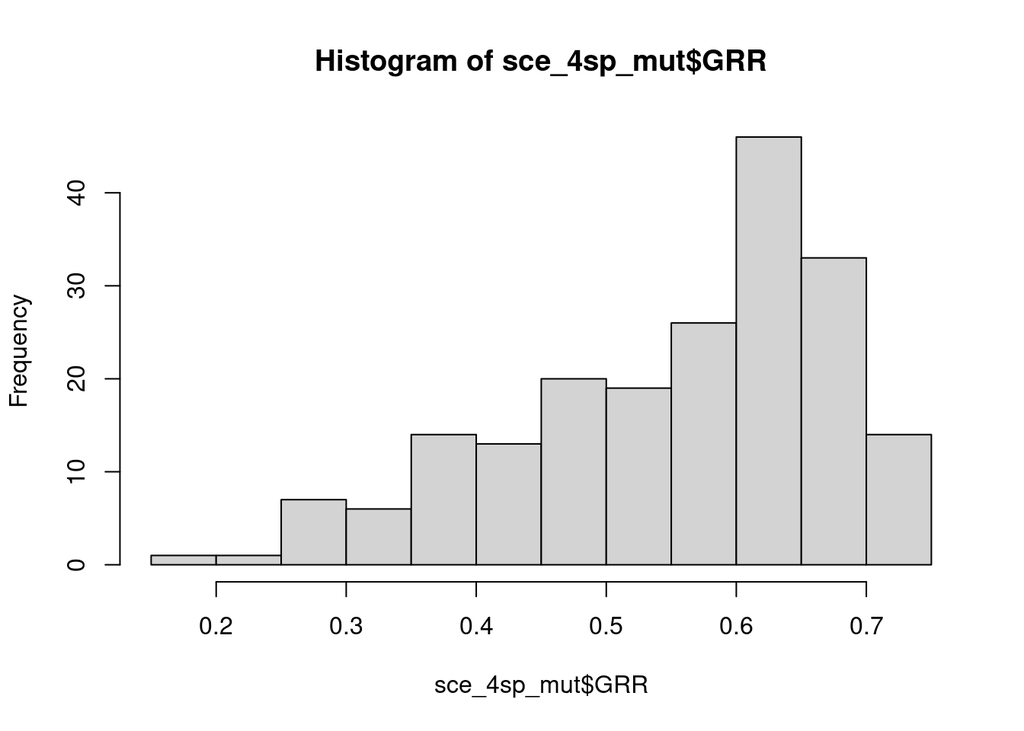

```r
sce_4sp_mut$GRR <- scsig.aucs[colnames(sce_4sp_mut),"GRR"]

sce_4sp_mut$GRR |> hist()
```

```r
sce_4sp_mut$GRR_group <- ifelse(sce_4sp_mut$GRR > 0.6,"hi","lo")

m.out <- scoreMarkers(sce_4sp_mut, sce_4sp_mut$GRR_group, block=sce_4sp_mut$batch)
```

[output not shown]

[output cut: 43 more lines]

[output not shown]

```r
m.out$lo |>
  as_tibble(rownames="feature") |>
  dplyr::filter(str_detect(feature,"ENSMUSG")) |>
  slice_min(rank.logFC.cohen,n = 25) |>
  pull(feature) |>
  walk(message)
```

```
ENSMUSG00000043050
```

```
ENSMUSG00000022501
```

```
ENSMUSG00000038015
```

```
ENSMUSG00000098178
```

```
ENSMUSG00000026182
```

```
ENSMUSG00000074435
```

```
ENSMUSG00000064357
```

```
ENSMUSG00000030206
```

```
ENSMUSG00000105361
```

```
ENSMUSG00000064351
```

```
ENSMUSG00000064363
```

```
ENSMUSG00000064370
```

```
ENSMUSG00000064354
```

```
ENSMUSG00000064367
```

```
ENSMUSG00000118396
```

```
ENSMUSG00000064345
```

```
ENSMUSG00000025551
```

```
ENSMUSG00000048686
```

```
ENSMUSG00000064358
```

```
ENSMUSG00000038523
```

```
ENSMUSG00000038994
```

```
ENSMUSG00000073731
```

```
ENSMUSG00000021203
```

```
ENSMUSG00000022748
```

```
ENSMUSG00000030990
```